# Introduction to Data Management

2016-11-16

[figure not shown]

## Caveat

**You are guinea pigs!**

## The day

- Introduction to data management
- File organisation best-practices
  - *Hands-on session*
- Version control — introduction to git and GitHub
  - *Hands-on session*

– *Lunch* –

- Notebooks - R notebook
  - *Hands-on session*
- Data publishing
- Collaborative environments
  - *Hands-on session*

## Introduction to Data Management

## Why manage research data?

- To make your research easier!
- To stop yourself drowning in irrelevant stuff
- In case you need the data later
- To avoid accusations of fraud or bad science
- To share your data for others to use and learn from
- To get credit for producing it
- Because funders or your organisation require it

Well-managed data opens up opportunities for re-use, integration and new science

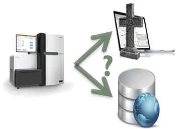

## Open Access to research data

- The practice of providing on-line access to scientific information that is free of charge to the end-user and that is re-usable.
  - Does not necessarily mean unrestricted access, e.g. for sensitive personal data
- Strong international movement towards Open Access (OA)
- European Commission recommended the member states to establish national guidelines for OA
  - Swedish Research Council (VR) submitted proposal to the government last year

[figure not shown]

[figure not shown]

[figure not shown]

## Why Open Access

- Democracy and transparency
  - Publicly funded research data should be accessible to all
  - Published results and conclusions should be possible to check by others
- Research
  - Enables others to combine data, address new questions, and develop new analytical methods
  - Reduce duplication and waste
- Innovation and utilization outside research
  - Public authorities, companies, and private persons outside research can make use of the data
- Citation
  - Citation of data will be a merit for the researcher that produced it

[figure not shown]

## Data loss

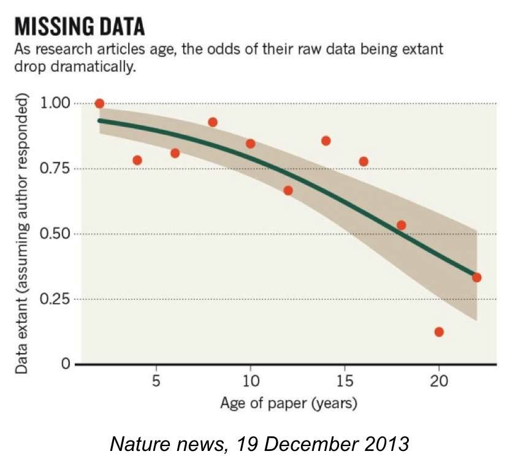

[figure not shown]

*Slide stolen from Barend Mons*

## Data persistency issues

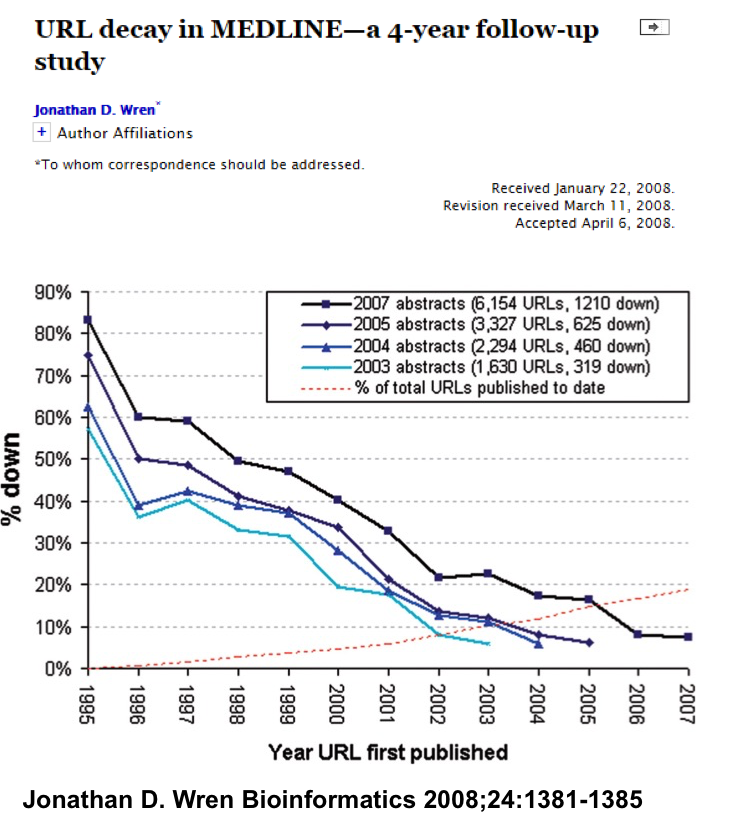

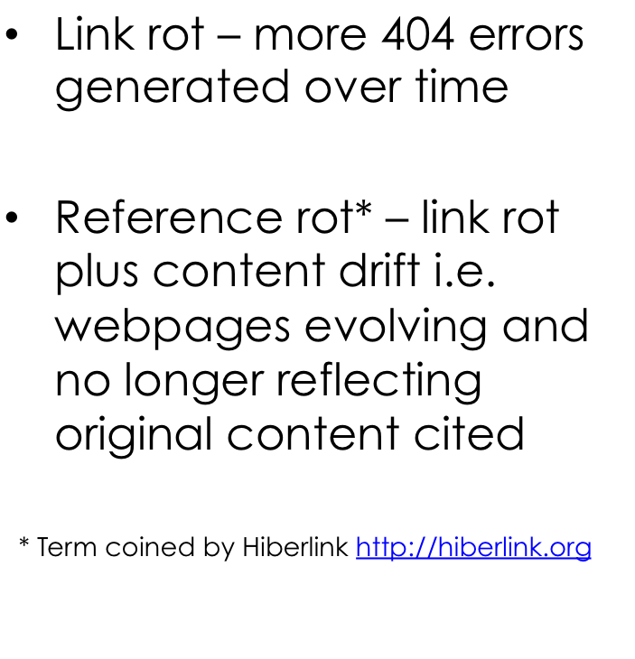

## The Research Data Life Cycle

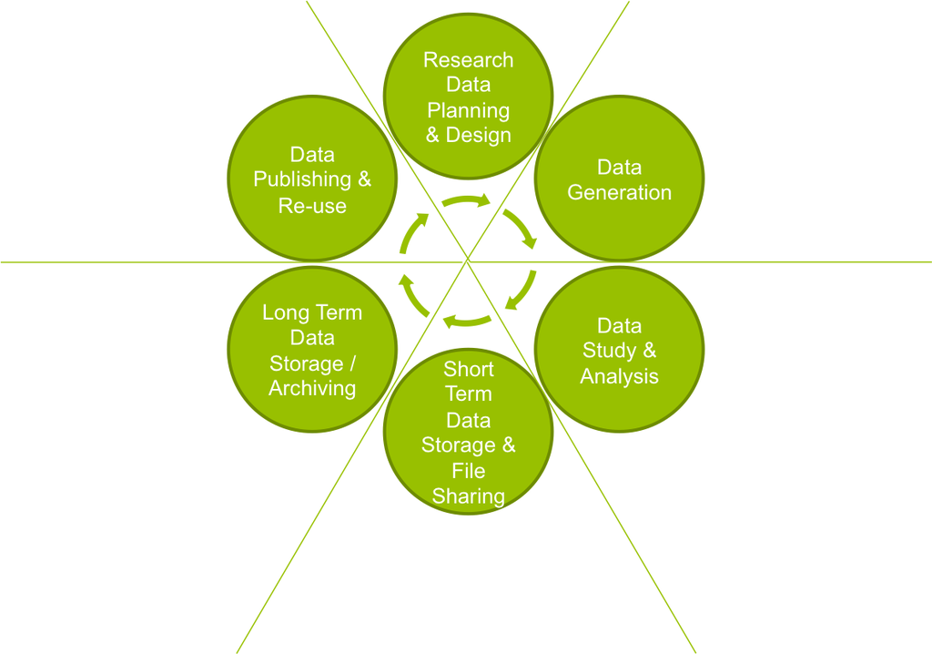

## Planning & Design

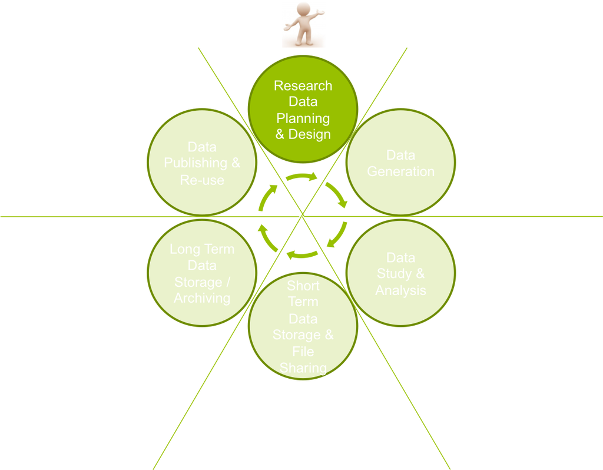

## Planning & Design

- Data Management planning
  - Data types
    - Sizes, were to store, etc
  - **Metadata**
    - Use standards!
      - *But not always straight-forward…*
      - (http://www.dcc.ac.uk/resources/metadata-standards/disciplinary/ecology)
- **Data Management Plans**
  - Will become a standard part of the research funding application process
  - What will be collected?, Organized?, Documented?, Stored and preserved?, Disseminated?, Policies?, Budget?

[figure not shown]

## Source acknowledgements

- Research Data Management, EUDAT - http://hdl.handle.net/11304/79db27e2-c12a-11e5-9bb4-2b0aad496318
- Barend Mons – FAIR Data